fossil

# DNA-binding proteins by PSSM distance, dug back up.

Xu and colleagues told DNA-binding proteins from others by their evolutionary profiles. The code and the web server are gone. We rebuilt the method from the paper, made the 1,261 profiles again against a 2014 protein database, and checked 28 of its 34 results.

See every result

## Fig. 1

Fig. 1. ACC (black) and MCC (red) of SVM-PSSM-DT against the largest lag LG, 5-fold cross validation on the benchmark.

Agreeson review

Published

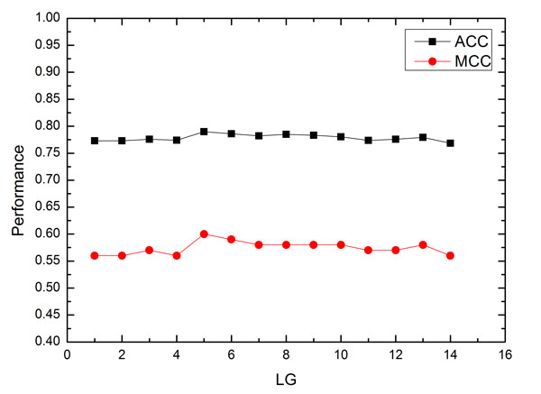

Our run

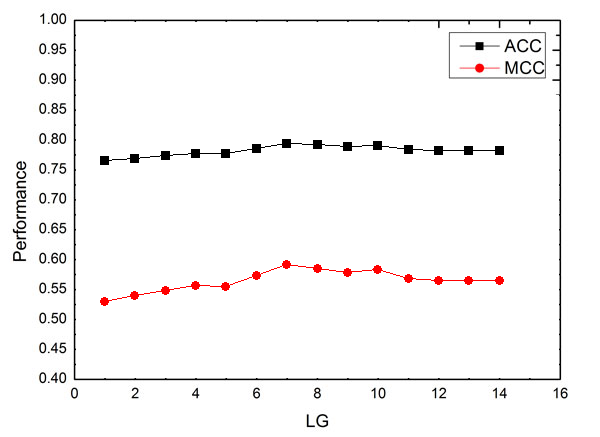

**Fig. 1, ACC and MCC against LG**

12 of 28 values, Agrees

Our curve has the published level (ACC 0.76 to 0.79, MCC 0.53 to 0.59) and is as flat, but between 5-fold splits single ACC values move by up to 0.02 and MCC values by up to 0.04, more than most gaps to the paper.

## Fig. 2

Fig. 2. (A) Discriminant weight of the 400 amino-acid pairs; (B) weight of the top four pairs at each lag. Panels C and D are left as published; their occurrences are checked as values below.

Differson review

Published

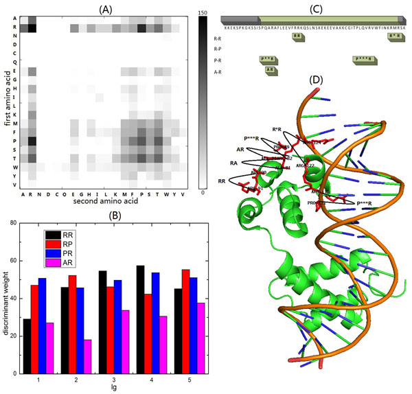

Our run

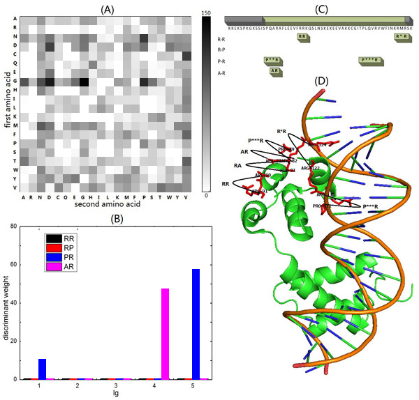

**Fig. 2A, discriminant weights of the 400 pairs**

0 of 4 values, Differs

**Fig. 2B, weights of the top four pairs by lg**

0 of 2 values, Differs

**Fig. 2C and text, descriptor occurrences on 1AKH chain A**

1 of 4 values, Partly agrees

Our largest pair weights are (G,G), (G,D), (G,P) and (N,P). (R,R) and (R,P) have no positive descriptor weight at all (pair weight 0, tied last), and (P,R) and (A,R) rank 133 and 176 of 400. Products of raw log-odds scores do not grow with arginine content (two negative R scores multiply to a large positive), and no variant of Eq. 12 we tried brings the four pairs to the top. Read as a linear grey scale, the published Fig. 2A itself puts (R,R), (P,R) and (R,P) on top and (A,R) eighth (published_values.json, fig2). Our (R,R) descriptor weights are negative at every lg, so (R,R) has no positive weight to peak; (A,R) peaks at lg 4, not 5. (R,R) and (R,P) have no positive descriptor weight at all (pair weight 0, tied last), and (P,R) and (A,R) rank 133 and 176 of 400. Products of raw log-odds scores do not grow with arginine content (two negative R scores multiply to a large positive), and no variant of Eq. 12 we tried brings the four pairs to the top. Read as a linear grey scale, the published Fig. 2A itself puts (R,R), (P,R) and (R,P) on top and (A,R) eighth (published_values.json, fig2). The five occurrences come back; the text gives three of their lags off by one ((R,R) lg 3 for lg 2, (P,R) lg 2 and 3 for lg 3 and 4). Whether all five lie in the DNA-binding region depends on how the region is drawn, which the paper does not say: by contact with the DNA in the crystal structure, (R,R) lg 1 (R25, R26), which the text calls very close to the DNA, is 13.2 A away, so four are in and one is out; by the span of contacts, all five are in.

## Fig. 3

Fig. 3. ROC curves of five PSSM encodings, jackknife on the benchmark.

Differson review

Published

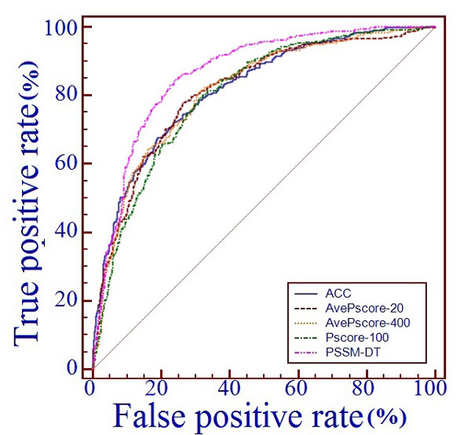

Our run

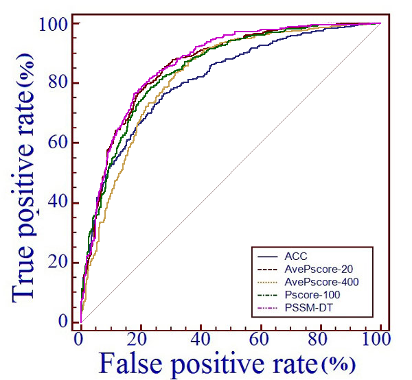

**Fig. 3, PSSM-DT ROC curve**

59.8% within 2 px (pass 75%), Partly agrees

**Fig. 3, ACC ROC curve**

63.7% within 2 px (pass 75%), Partly agrees

**Fig. 3, AvePscore-20 ROC curve**

9.9% within 2 px (pass 75%), Differs

**Fig. 3, AvePscore-400 ROC curve**

13.7% within 2 px (pass 75%), Inconclusive

**Fig. 3, Pscore-100 ROC curve**

4.5% within 2 px (pass 75%), Inconclusive

Our PSSM-DT curve stays within about 2 points of true positive rate of the published one (AUC 86.34 against 86.50), lowest between 15 and 30% false positives, where our specificity is lower (scores.json, tpr_gap). At 2 px that clears the wrong-input control by only a little. Same causes as Table 1. Our ACC encoding is the one comparator that comes close: AUC 81.02 against 81.90, ACC 73.49 against 73.77, and its curve runs near the published one. The other comparators lie above theirs. The paper's implementations are known only by citation. Our AvePscore and Pscore curves lie above the published ones, as their AUCs in Table 2 do (AvePscore-20 85.68 against 81.40, AvePscore-400 82.09 against 81.50, Pscore-100 84.53 against 80.50). The paper's implementations are known only by citation.

## Fig. 4

Fig. 4. ROC curves of the predictors, jackknife on the benchmark. Our DNAbinder curves are the AvePscore curves of Fig. 3; DNA-Prot and iDNA-Prot were not rebuilt.

Differson review

Published

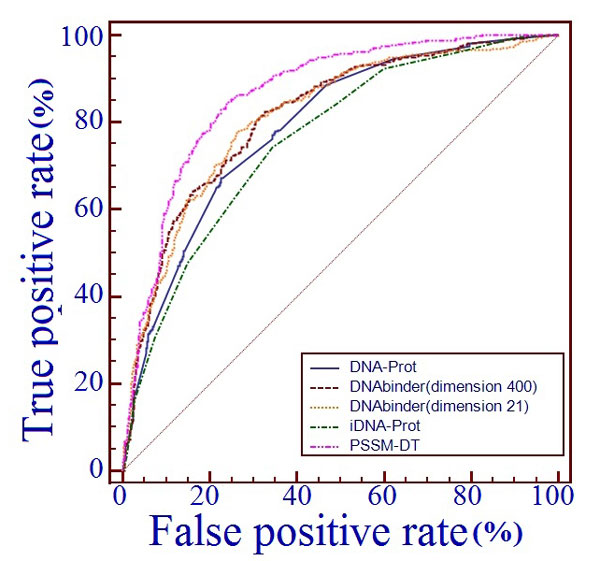

Our run

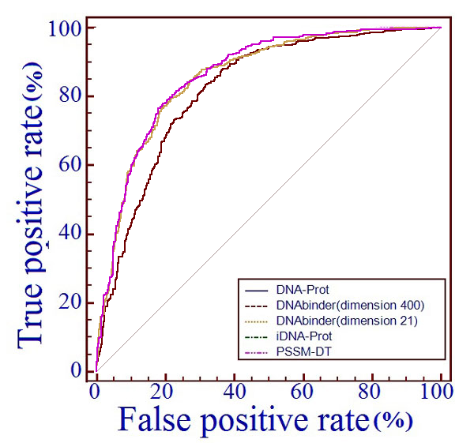

**Fig. 4, PSSM-DT ROC curve**

61.6% within 2 px (pass 75%), Partly agrees

**Fig. 4, DNAbinder(dimension 21) ROC curve**

3.3% within 2 px (pass 75%), Differs

**Fig. 4, DNAbinder(dimension 400) ROC curve**

13.8% within 2 px (pass 75%), Differs

Our PSSM-DT curve stays within about 2 points of true positive rate of the published one (AUC 86.34 against 86.50), lowest between 15 and 30% false positives, where our specificity is lower (scores.json, tpr_gap). At 2 px that clears the wrong-input control by only a little. Same causes as Table 1. Our AvePscore and Pscore curves lie above the published ones, as their AUCs in Table 2 do (AvePscore-20 85.68 against 81.40, AvePscore-400 82.09 against 81.50, Pscore-100 84.53 against 80.50). The paper's implementations are known only by citation.

## Fig. 5

Fig. 5. ROC curves on PDB186. DBPPred, DNABIND and DNAbinder from the outputs Lou et al. published; PSSM-DT from our model; DNA-Prot and iDNA-Prot were not rebuilt.

Differson review

Published

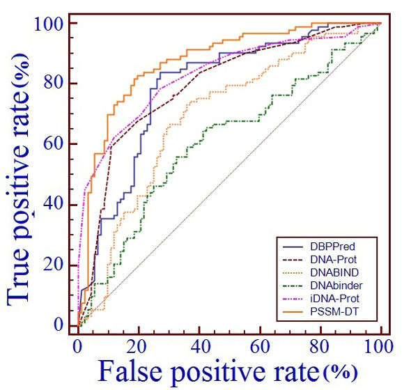

Our run

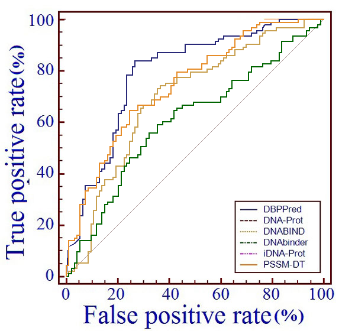

**Fig. 5, PSSM-DT ROC curve**

13.3% within 2 px (pass 75%), Differs

**Fig. 5, DBPPred ROC curve**

97.4% within 2 px (pass 75%), Agrees

**Fig. 5, DNABIND ROC curve**

78.1% within 2 px (pass 75%), Agrees

**Fig. 5, DNAbinder ROC curve**

82.2% within 2 px (pass 75%), Agrees

On PDB186 our model gets ACC 66.13 and AUC 74.44 against the paper's 80.00 and 87.40, below DBPPred (76.88, 79.29). No identity threshold for the homology filter brings it back: AUC stays between 74.4 and 76.0 for thresholds of 25 to 99%, and only training on the unfiltered benchmark, which shares 42 chains with PDB186, reaches 81.49 (87.46 with UniRef90 PSSMs). The paper does not report how many chains its filter removed.

## Every result

Every figure, table and claim of the paper, with the paper's numbers next to ours. Numbers that the paper's own tables contradict are kept but not counted.

Result

Verdict

Measure

Why

Benchmark and PDB186 sizes

Exact

4 of 4 values

- benchmark DNA-binding chains: paper 525, ours **525**
- benchmark non-binding chains: paper 550, ours **550**
- PDB186 DNA-binding chains: paper 93, ours **93**
- PDB186 non-binding chains: paper 93, ours **93**

Fig. 1, ACC and MCC against LG

Agreeson review

12 of 28 values

- ACC at LG 1: paper 0.773, ours **0.7647**
- MCC at LG 1: paper 0.56, ours **0.5299**
- ACC at LG 2: paper 0.773, ours **0.7693**
- MCC at LG 2: paper 0.56, ours **0.5403**
- ACC at LG 3: paper 0.776, ours **0.774**
- MCC at LG 3: paper 0.57, ours **0.5487**
- ACC at LG 4: paper 0.774, ours **0.7777**
- MCC at LG 4: paper 0.56, ours **0.5568**
- ACC at LG 5: paper 0.79, ours **0.7767**
- MCC at LG 5: paper 0.6, ours **0.555**
- ACC at LG 6: paper 0.787, ours **0.786**
- MCC at LG 6: paper 0.59, ours **0.5735**
- ACC at LG 7: paper 0.783, ours **0.7944**
- MCC at LG 7: paper 0.58, ours **0.5911**
- ACC at LG 8: paper 0.785, ours **0.7916**
- MCC at LG 8: paper 0.58, ours **0.585**
- ACC at LG 9: paper 0.784, ours **0.7879**
- MCC at LG 9: paper 0.58, ours **0.5775**
- ACC at LG 10: paper 0.78, ours **0.7907**
- MCC at LG 10: paper 0.58, ours **0.5834**
- ACC at LG 11: paper 0.773, ours **0.7833**
- MCC at LG 11: paper 0.57, ours **0.5672**
- ACC at LG 12: paper 0.776, ours **0.7814**
- MCC at LG 12: paper 0.57, ours **0.5639**
- ACC at LG 13: paper 0.78, ours **0.7814**
- MCC at LG 13: paper 0.58, ours **0.5642**
- ACC at LG 14: paper 0.768, ours **0.7814**
- MCC at LG 14: paper 0.56, ours **0.5638**

Our curve has the published level (ACC 0.76 to 0.79, MCC 0.53 to 0.59) and is as flat, but between 5-fold splits single ACC values move by up to 0.02 and MCC values by up to 0.04, more than most gaps to the paper.

Best LG is 5 (text and Fig. 1)

Differs

0 of 2 values

- LG with the highest ACC: paper 5, ours **7**
- LG with the highest MCC: paper 5, ours **7**

No split of ours puts the optimum at LG 5: the best LG is 7, 6, 8, 6 and 7 on five splits, and LG 5 is within 0.02 ACC of the best on every split. The paper's peak at LG 5 is a 0.016 rise over LG 4 that our runs do not show.

Table 1, PSSM-DT, PSSM-DDT and PSSM-SDT (jackknife)

Differson review

0 of 12 values

- PSSM-DDT ACC: paper 79.72, ours **78.51**
- PSSM-DDT MCC: paper 0.607, ours **0.572**
- PSSM-DDT SN: paper 81.33, ours **81.71**
- PSSM-DDT SP: paper 78.18, ours **75.45**
- PSSM-SDT ACC: paper 74.79, ours **76.56**
- PSSM-SDT MCC: paper 0.512, ours **0.532**
- PSSM-SDT SN: paper 77.147, ours **78.86**
- PSSM-SDT SP: paper 74.93, ours **74.36**
- PSSM-DT ACC: paper 79.96, ours **78.88**
- PSSM-DT MCC: paper 0.622, ours **0.58**
- PSSM-DT SN: paper 81.91, ours **82.1**
- PSSM-DT SP: paper 78.00, ours **75.82**

PSSM-DT comes back within about 2 points: ACC 78.88 against 79.96, SN 82.10 against 81.91 (one chain more), SP 75.82 against 78.00 (12 chains fewer), AUC 86.34 against 86.50. No value matches at the printed precision. Five printed ACC and MCC values do not follow from the printed SN and SP and are left out of the count. The PSSMs of the 2014 nr cannot be rebuilt; each other unstated setting moves ACC by at most 1.3 points and none closes the gap in all four metrics.

Table 2, five PSSM encodings (jackknife)

Differson review

0 of 25 values

- AvePscore-20 ACC: paper 73.95, ours **78.33**
- AvePscore-20 MCC: paper 0.480, ours **0.567**
- AvePscore-20 SN: paper 68.57, ours **80**
- AvePscore-20 SP: paper 79.09, ours **76.73**
- AvePscore-20 AUC: paper 81.40, ours **85.68**
- AvePscore-400 ACC: paper 73.58, ours **74.88**
- AvePscore-400 MCC: paper 0.470, ours **0.499**
- AvePscore-400 SN: paper 66.47, ours **77.14**
- AvePscore-400 SP: paper 80.36, ours **72.73**
- AvePscore-400 AUC: paper 81.50, ours **82.09**
- Pscore-100 ACC: paper 73.12, ours **77.4**
- Pscore-100 MCC: paper 0.463, ours **0.548**
- Pscore-100 SN: paper 72.76, ours **77.33**
- Pscore-100 SP: paper 73.45, ours **77.45**
- Pscore-100 AUC: paper 80.50, ours **84.53**
- ACC ACC: paper 73.77, ours **73.49**
- ACC MCC: paper 0.475, ours **0.469**
- ACC SN: paper 73.14, ours **70.48**
- ACC SP: paper 74.36, ours **76.36**
- ACC AUC: paper 81.90, ours **81.02**
- PSSM-DT ACC: paper 79.96, ours **78.88**
- PSSM-DT MCC: paper 0.622, ours **0.58**
- PSSM-DT SN: paper 81.91, ours **82.1**
- PSSM-DT SP: paper 78.00, ours **75.82**
- PSSM-DT AUC: paper 86.50, ours **86.34**

Our comparator encodings, built as Lou et al. 2014 define them, score far above the paper's in-house versions: AvePscore-20 78.33 ACC and 85.68 AUC against 73.95 and 81.40, Pscore-100 77.40 and 84.53 against 73.12 and 80.50. ACC (73.49 and 81.02 against 73.77 and 81.90) and AvePscore-400 come closer. The paper's implementations are not given beyond citations, so its lead of 6 ACC points shrinks to 0.56 in our run.

Table 3, DNAbinder rows (jackknife)

Differson review

0 of 10 values

- DNAbinder(dimension 21) ACC: paper 73.95, ours **78.33**
- DNAbinder(dimension 21) MCC: paper 0.480, ours **0.567**
- DNAbinder(dimension 21) SN: paper 68.57, ours **80**
- DNAbinder(dimension 21) SP: paper 79.09, ours **76.73**
- DNAbinder(dimension 21) AUC: paper 81.40, ours **85.68**
- DNAbinder(dimension 400) ACC: paper 73.58, ours **74.88**
- DNAbinder(dimension 400) MCC: paper 0.470, ours **0.499**
- DNAbinder(dimension 400) SN: paper 66.47, ours **77.14**
- DNAbinder(dimension 400) SP: paper 80.36, ours **72.73**
- DNAbinder(dimension 400) AUC: paper 81.50, ours **82.09**

Our comparator encodings, built as Lou et al. 2014 define them, score far above the paper's in-house versions: AvePscore-20 78.33 ACC and 85.68 AUC against 73.95 and 81.40, Pscore-100 77.40 and 84.53 against 73.12 and 80.50. ACC (73.49 and 81.02 against 73.77 and 81.90) and AvePscore-400 come closer. The paper's implementations are not given beyond citations, so its lead of 6 ACC points shrinks to 0.56 in our run.

Table 3, DNA-Prot and iDNA-Prot rows

Not attempted

The paper's in-house DNA-Prot and iDNA-Prot are given only as citations (random forests on composition, predicted secondary structure and physicochemical or grey-model features, settings not stated). A rebuild would test our reading of two other papers, not this one. Their printed ACC does not follow from their own SN and SP (72.55 against 70.98, 75.40 against 74.05).

Table 4, the six earlier predictors on PDB186

Exact

25 of 27 values

- iDNA-Prot ACC: paper 67.20, ours **67.2043**
- iDNA-Prot MCC: paper 0.344, ours **0.3441**
- iDNA-Prot SN: paper 67.70, ours **67.7419**
- iDNA-Prot SP: paper 66.70, ours **66.6667**
- DNA-Prot ACC: paper 61.80, ours **61.828**
- DNA-Prot MCC: paper 0.240, ours **0.2397**
- DNA-Prot SN: paper 69.90, ours **69.8925**
- DNA-Prot SP: paper 53.80, ours **53.7634**
- DNAbinder ACC: paper 60.80, ours **60.7527**
- DNAbinder MCC: paper 0.216, ours **0.2157**
- DNAbinder SN: paper 57.00, ours **56.9892**
- DNAbinder SP: paper 64.50, ours **64.5161**
- DNAbinder AUC: paper 60.70, ours **60.7238**
- DNABIND ACC: paper 67.70, ours **67.7419**
- DNABIND MCC: paper 0.355, ours **0.3549**
- DNABIND SN: paper 66.70, ours **66.6667**
- DNABIND SP: paper 68.80, ours **68.8172**
- DNABIND AUC: paper 69.40, ours **69.4762**
- DNA-Threader ACC: paper 59.70, ours **59.6774**
- DNA-Threader MCC: paper 0.279, ours **0.2791**
- DNA-Threader SN: paper 23.70, ours **23.6559**
- DNA-Threader SP: paper 95.70, ours **95.6989**
- DBPPred ACC: paper 76.90, ours **76.8817**
- DBPPred MCC: paper 0.538, ours **0.5384**
- DBPPred SN: paper 79.60, ours **79.5699**
- DBPPred SP: paper 74.20, ours **74.1935**
- DBPPred AUC: paper 79.10, ours **79.2924**

Table 4, PSSM-DT on PDB186

Differs

0 of 5 values

- PSSM-DT ACC: paper 80.00, ours **66.13**
- PSSM-DT MCC: paper 0.647, ours **0.324**
- PSSM-DT SN: paper 87.09, ours **69.89**
- PSSM-DT SP: paper 72.83, ours **62.37**
- PSSM-DT AUC: paper 87.40, ours **74.44**

On PDB186 our model gets ACC 66.13 and AUC 74.44 against the paper's 80.00 and 87.40, below DBPPred (76.88, 79.29). No identity threshold for the homology filter brings it back: AUC stays between 74.4 and 76.0 for thresholds of 25 to 99%, and only training on the unfiltered benchmark, which shares 42 chains with PDB186, reaches 81.49 (87.46 with UniRef90 PSSMs). The paper does not report how many chains its filter removed.

Table 4, AUC of iDNA-Prot and DNA-Prot

Not attempted

Table 4 says its comparator rows come from Lou et al. 2014, but Lou et al. print N/A for the AUC of iDNA-Prot and DNA-Prot and publish no real-valued outputs for them; the 83.30 and 79.60 come from the authors' in-house versions, which are not available.

Fig. 2A, discriminant weights of the 400 pairs

Differs

0 of 4 values

- (R,R) among the four pairs with the largest weight: paper yes, ours **no**
- (R,P) among the four pairs with the largest weight: paper yes, ours **no**
- (P,R) among the four pairs with the largest weight: paper yes, ours **no**
- (A,R) among the four pairs with the largest weight: paper yes, ours **no**

Our largest pair weights are (G,G), (G,D), (G,P) and (N,P). (R,R) and (R,P) have no positive descriptor weight at all (pair weight 0, tied last), and (P,R) and (A,R) rank 133 and 176 of 400. Products of raw log-odds scores do not grow with arginine content (two negative R scores multiply to a large positive), and no variant of Eq. 12 we tried brings the four pairs to the top. Read as a linear grey scale, the published Fig. 2A itself puts (R,R), (P,R) and (R,P) on top and (A,R) eighth (published_values.json, fig2).

Fig. 2B, weights of the top four pairs by lg

Differs

0 of 2 values

- lg with the largest (R,R) weight: paper 4, ours **none (no positive weight)**
- lg with the largest (A,R) weight: paper 5, ours **4**

Our (R,R) descriptor weights are negative at every lg, so (R,R) has no positive weight to peak; (A,R) peaks at lg 4, not 5. (R,R) and (R,P) have no positive descriptor weight at all (pair weight 0, tied last), and (P,R) and (A,R) rank 133 and 176 of 400. Products of raw log-odds scores do not grow with arginine content (two negative R scores multiply to a large positive), and no variant of Eq. 12 we tried brings the four pairs to the top. Read as a linear grey scale, the published Fig. 2A itself puts (R,R), (P,R) and (R,P) on top and (A,R) eighth (published_values.json, fig2).

Fig. 2C and text, descriptor occurrences on 1AKH chain A

Partly agreeson review

1 of 4 values

- occurrences of the four pairs (lg 1 to 5) on 1AKH chain A: paper 5, ours **5**
- occurrences listed (pair and lg): paper AR1, PR2, PR3, RR1, RR3, ours **AR1, PR3, PR4, RR1, RR2**
- occurrences in the DNA-binding region (residues within 4.5 A of DNA, our definition): paper 5, ours **4**
- occurrences outside it: paper 0, ours **1**

The five occurrences come back; the text gives three of their lags off by one ((R,R) lg 3 for lg 2, (P,R) lg 2 and 3 for lg 3 and 4). Whether all five lie in the DNA-binding region depends on how the region is drawn, which the paper does not say: by contact with the DNA in the crystal structure, (R,R) lg 1 (R25, R26), which the text calls very close to the DNA, is 13.2 A away, so four are in and one is out; by the span of contacts, all five are in.

Fig. 2D, the occurrences drawn on the 1AKH structure

Not attempted

A drawing of panel C's occurrences on the 1AKH structure; the distances it illustrates are checked in Fig. 2C.

Fig. 3, PSSM-DT ROC curve

Partly agrees

59.8% within 2 px (pass 75%)

Our PSSM-DT curve stays within about 2 points of true positive rate of the published one (AUC 86.34 against 86.50), lowest between 15 and 30% false positives, where our specificity is lower (scores.json, tpr_gap). At 2 px that clears the wrong-input control by only a little. Same causes as Table 1.

Fig. 3, ACC ROC curve

Partly agrees

63.7% within 2 px (pass 75%)

Our ACC encoding is the one comparator that comes close: AUC 81.02 against 81.90, ACC 73.49 against 73.77, and its curve runs near the published one. The other comparators lie above theirs. The paper's implementations are known only by citation.

Fig. 3, AvePscore-20 ROC curve

Differson review

9.9% within 2 px (pass 75%)

Our AvePscore and Pscore curves lie above the published ones, as their AUCs in Table 2 do (AvePscore-20 85.68 against 81.40, AvePscore-400 82.09 against 81.50, Pscore-100 84.53 against 80.50). The paper's implementations are known only by citation.

Fig. 3, AvePscore-400 ROC curve

Inconclusive

13.7% within 2 px (pass 75%)

Our AvePscore and Pscore curves lie above the published ones, as their AUCs in Table 2 do (AvePscore-20 85.68 against 81.40, AvePscore-400 82.09 against 81.50, Pscore-100 84.53 against 80.50). The paper's implementations are known only by citation.

Fig. 3, Pscore-100 ROC curve

Inconclusive

4.5% within 2 px (pass 75%)

Our AvePscore and Pscore curves lie above the published ones, as their AUCs in Table 2 do (AvePscore-20 85.68 against 81.40, AvePscore-400 82.09 against 81.50, Pscore-100 84.53 against 80.50). The paper's implementations are known only by citation.

Fig. 4, PSSM-DT ROC curve

Partly agreeson review

61.6% within 2 px (pass 75%)

Our PSSM-DT curve stays within about 2 points of true positive rate of the published one (AUC 86.34 against 86.50), lowest between 15 and 30% false positives, where our specificity is lower (scores.json, tpr_gap). At 2 px that clears the wrong-input control by only a little. Same causes as Table 1.

Fig. 4, DNAbinder(dimension 21) ROC curve

Differs

3.3% within 2 px (pass 75%)

Our AvePscore and Pscore curves lie above the published ones, as their AUCs in Table 2 do (AvePscore-20 85.68 against 81.40, AvePscore-400 82.09 against 81.50, Pscore-100 84.53 against 80.50). The paper's implementations are known only by citation.

Fig. 4, DNAbinder(dimension 400) ROC curve

Differson review

13.8% within 2 px (pass 75%)

Our AvePscore and Pscore curves lie above the published ones, as their AUCs in Table 2 do (AvePscore-20 85.68 against 81.40, AvePscore-400 82.09 against 81.50, Pscore-100 84.53 against 80.50). The paper's implementations are known only by citation.

Fig. 5, PSSM-DT ROC curve

Differs

13.3% within 2 px (pass 75%)

On PDB186 our model gets ACC 66.13 and AUC 74.44 against the paper's 80.00 and 87.40, below DBPPred (76.88, 79.29). No identity threshold for the homology filter brings it back: AUC stays between 74.4 and 76.0 for thresholds of 25 to 99%, and only training on the unfiltered benchmark, which shares 42 chains with PDB186, reaches 81.49 (87.46 with UniRef90 PSSMs). The paper does not report how many chains its filter removed.

Fig. 5, DBPPred ROC curve

Agreeson review

97.4% within 2 px (pass 75%)

Fig. 5, DNABIND ROC curve

Agreeson review

78.1% within 2 px (pass 75%)

Fig. 5, DNAbinder ROC curve

Agreeson review

82.2% within 2 px (pass 75%)

Fig. 4, DNA-Prot and iDNA-Prot ROC curves

Not attempted

The DNA-Prot and iDNA-Prot curves come from the authors' in-house versions of those predictors, which were not rebuilt (Table 3).

Fig. 5, DNA-Prot and iDNA-Prot ROC curves

Not attempted

The DNA-Prot and iDNA-Prot curves come from the authors' in-house versions of those predictors, which were not rebuilt (Table 3).

Fig. 6, the web server's home page

Not attempted

A screenshot of the web server, which no longer answers.

PSSM-DT beats the four other encodings and its two halves (text, Tables 1 to 3)

Differson review

4 of 6 values

- PSSM-DT ACC above all four other encodings: paper yes, ours **yes**
- PSSM-DT MCC above all four other encodings: paper yes, ours **yes**
- PSSM-DT AUC above all four other encodings: paper yes, ours **yes**
- ACC gain over the best other encoding (points): paper 6.01, ours **0.56**
- AUC gain over the best other encoding (points): paper 4.60, ours **0.66**
- PSSM-DT ACC above PSSM-DDT and PSSM-SDT: paper yes, ours **yes**

Our comparator encodings, built as Lou et al. 2014 define them, score far above the paper's in-house versions: AvePscore-20 78.33 ACC and 85.68 AUC against 73.95 and 81.40, Pscore-100 77.40 and 84.53 against 73.12 and 80.50. ACC (73.49 and 81.02 against 73.77 and 81.90) and AvePscore-400 come closer. The paper's implementations are not given beyond citations, so its lead of 6 ACC points shrinks to 0.56 in our run.

PSSM-DT is best on PDB186 (text, Table 4)

Differs

0 of 6 values

- PSSM-DT ACC above the six other predictors: paper yes, ours **no**
- PSSM-DT MCC above the six other predictors: paper yes, ours **no**
- PSSM-DT AUC above DBPPred, DNAbinder and DNABIND: paper yes, ours **no**
- ACC gain over DBPPred (points): paper 3.105, ours **-10.753**
- MCC gain over DBPPred: paper 0.136, ours **-0.215**
- AUC gain over DBPPred (points): paper 8.30, ours **-4.86**

On PDB186 our model gets ACC 66.13 and AUC 74.44 against the paper's 80.00 and 87.40, below DBPPred (76.88, 79.29). No identity threshold for the homology filter brings it back: AUC stays between 74.4 and 76.0 for thresholds of 25 to 99%, and only training on the unfiltered benchmark, which shares 42 chains with PDB186, reaches 81.49 (87.46 with UniRef90 PSSMs). The paper does not report how many chains its filter removed.

Claims recomputed from the paper's own tables

Agrees

PSSM-DT as in the authors' later toolkit (BioSeq-Analysis2.0)

Agrees

Python package pssmdt and its tutorial

Agrees

PSSM-DT still beats the four earlier encodings in our run, but by half a point, not six. The PDB186 result does not come back. Causes: the comparators the authors built in house, and a homology filter that cannot run as written.

## What came back

**The benchmark**

All 1,075 chains, 525 and 550, read from the supplement.

**PSSM-DT on the benchmark**

ACC 78.88, SN 82.10, SP 75.82, AUC 86.34 by jackknife, within about 2 points of the paper.

**Table 4, earlier predictors**

Every row recomputed from the outputs Lou and colleagues published.

**Fig. 5, three curves**

DBPPred, DNABIND and DNAbinder drawn from those outputs land on the published curves.

**The method**

PSSM-DT as a Python package, the same as the authors' later toolkit computes it.

## What stayed buried

- The 2014 protein database the profiles were made from; nobody kept it.
- DNA-Prot and iDNA-Prot as the authors rebuilt them.
- The size of the paper's six point lead over the other encodings.
- The PDB186 result: our model scores below the earlier predictors there.
- The four amino-acid pairs of Fig. 2; our model weighs others.

PSSM-DT still beats the four earlier encodings in our run, but by half a point, not six. The PDB186 result does not come back. Causes: the comparators the authors built in house, and a homology filter that cannot run as written.

Some numbers in the paper do not follow from its own tables. We list them so nobody chases them.

**Table 1**

Five of its ACC and MCC values do not follow from the printed SN and SP.

**Table 4**

SP 72.83 is not a share of 93 chains, and the MCC is printed as 0.647 and as 0.674.

**Text**

The gains over DBPPred, 3.105 and 0.136, do not follow from Table 4.

**Fig. 2C**

The text gives three of the five pairs the wrong distance, off by one.